# Chapter 7 – Control Flow and Functions

Hannah Hodge Waller

**Chapter 7 – Control Flow and Functions**

This is a HTML document. The Introduction to Python course is written and intended to be used in a Jupyter Notebook file. These HTML documents have been made available for users who require screen readers or other accessibility needs. These HTML documents have been tested, but if you notice any errors or any compatibility issues please contact us on the GSS Capability email inbox. If you are using a screen reader you will need to set your punctuation level (sometimes called verbosity) to full, especially for the code sections.

Follow along with the code by running it in your software as you encounter it.

*Chapter Overview and Learning Objectives*:

- Packages and Data
  - Packages
  - Data
- Comparison and Logical Operators
  - Comparison operators
  - Logical operators
- Loops / Control Flow
  - For Loops
  - While Loops
  - If, Elif, Else
  - Exercise
  - List comprehension
- Functions
  - Basic structure
  - Named parameters
  - Default Values
  - Scope
  - Docstrings
  - Indentation
  - Exercise
- Functions for DataFrames

# 1 Packages and Datasets

## 1.1 Packages

As a reminder – we should always import our packages at the top of our script.

In this session we will use * `pandas`, and give it the nickname `pd`

## 1.2 Exercise

### **Packages**

Import Pandas and give it the nickname pd

### **Show Answer**

```python
import pandas as pd
```

## 1.3 Datasets

Good practice should also be to import our datasets at the top of our script too.

In this session we’ll be using:

| variable name | file name |
| --- | --- |
| animals | animals.csv |
| titanic | titanic.xlsx |

These are all straight forward data imports with no additional parameters.

Use the cell below to load in these datasets.

If you are stuck use the solution cell; remember practicing simple commands is important for retaining the skills you’re learning.

## 1.4 Exercise

### **Load in the Data**

Load in these datasets listed above

If you are stuck use the Show Answer tab; remember practicing simple commands is important for retaining the skills you’re learning.

You can check your variables are loaded by using `%whos` in Jupyter. In Spyder or other IDE’s they should appear in your variable explorer.

### **Show Answer**

```python
animals = pd.read_csv("../data/animals.csv")
titanic = pd.read_excel("../data/titanic.xlsx")
```

If you struggle with this section – review chapter 3 – Reading In and Exporting Data

return to menu

# 2 Comparison and Logical Operators

When we use control flow or functions, we will often use comparison operators.

As a reminder our comparison operators are:

| Operator | Description |
| --- | --- |
| == | Equivalent to |
| != | Not equivalent to |
| < | Less than |
| <= | Less than or equal to |
| > | Greater than |
| >= | Greater than or equal to |

Our comparison operators return us a Boolean value = `True` or `False`.

Test yourself to see if your prediction matches the results from the cell below.

```python
print(4 == 2)
```

```
## False
```

```python
print("Hannah" != "hannah")
```

```
## True
```

```python
print(True > False)
```

```
## True
```

```python
print(1 > 0) # Same as the one above - think about the numbers behind Boolean values
```

```
## True
```

This also applies to `pandas` Series where it checks each element individually.

```python
(titanic["sex"] == "female").head()
```

```
## 0     True
## 1    False
## 2     True
## 3    False
## 4     True
## Name: sex, dtype: bool
```

We also have our logical operators:

| Operator | Description |
| --- | --- |
| & | And |
| \| | Or |
| ! | Not |

We can use these to join our conditional statements, like we’ve seen when we did filters.

As a reminder of how these work - here’s our `Truth table` from chapter 4 again

| Condition 1 | Condition 2 | & (AND) Equates to | \| (OR) Equates to |
| --- | --- | --- | --- |
| True | True | True | True |
| True | False | False | True |
| False | True | False | True |
| False | False | False | False |

Here I’ve filtered the `titanic` dataframe to show female passengers with a recorded age under 18.

```python
titanic_f_kids = titanic[(titanic["sex"] == "female") & (titanic["age"] < 18)]

titanic_f_kids.head()
```

|  | pclass | survived | name | sex | age | sibsp | parch | ticket | fare | cabin | embarked | home.dest | body | boat |
| --- | --- | --- | --- | --- | --- | --- | --- | --- | --- | --- | --- | --- | --- | --- |
| 2 | 1 | 0 | Allison, Miss. Helen Loraine | female | 2 | 1 | 2 | 113781 | 151.5500 | C22 C26 | S | Montreal, PQ / Chesterville, ON | NaN | NaN |
| 55 | 1 | 1 | Carter, Miss. Lucile Polk | female | 14 | 1 | 2 | 113760 | 120.0000 | B96 B98 | S | Bryn Mawr, PA | NaN | 4 |
| 92 | 1 | 1 | Dick, Mrs. Albert Adrian (Vera Gillespie) | female | 17 | 1 | 0 | 17474 | 57.0000 | B20 | S | Calgary, AB | NaN | 3 |
| 159 | 1 | 1 | Hippach, Miss. Jean Gertrude | female | 16 | 0 | 1 | 111361 | 57.9792 | B18 | C | Chicago, IL | NaN | 4 |
| 187 | 1 | 1 | Lines, Miss. Mary Conover | female | 16 | 0 | 1 | PC 17592 | 39.4000 | D28 | S | Paris, France | NaN | 9 |

# 3 Loops / Control Flow

We use these conditional statements and comparison operators when we create loops and control flow.

Loops are useful for when we need to repeat a section of code, such as for each piece of data in a list.

Python gives us two forms of loops, a `for` loop and a `while` loop.

## 3.1 For Loops

`for` loops take each item in an iterable and repeat the action over it.

An iterable is something we can iterate over.

We’ve seen a few of these so far, thinks like strings or more commonly lists, tuples or ranges.

```python
for each_thing in my_iterable:
    do_this_action()
```

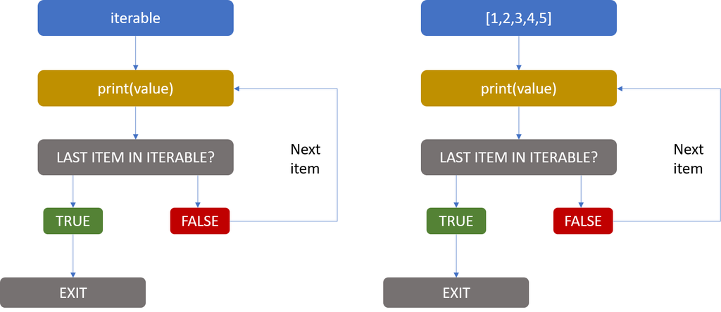

For Loop as a flow diagram

For loops start with the keyword `for`.

This is followed by a variable that refers to each item within my iterable in turn.

The keyword `in` is followed by the iterable I want to loop over.

The line is finished with a colon `:`. This tells python that whatever follows belongs to this loop.

The next lines contain the actions that will happen for each item in the iterable. This is indented by 4 spaces or a tab. Most code writing tools will automatically indent for you.

```python
# Create my iterable
number_list = [0, 1, 2, 3, 4, 5]

# Create my for loop
for each_number in number_list:
    print(each_number*2)
```

```
## 0
## 2
## 4
## 6
## 8
## 10
```

Here I’ve created a list called `number_list` with the numbers 0 to 5.

Again the keyword `for` is followed by a variable that refers to each item in my iterable at a given point in the loop. I’ve called this variable `each_number` . You’ll often see letters like `i` used here.

The keyword `in` is followed by the iterable I want to loop over and the line is finished with a colon `:` .

My action is indented (by 4 spaces or a tab – but Jupyter did this automatically), and tells the computer to use the `print()` function to print `each_number` multiplied by 2.

The following uses the built-in `range` function, and has the exact same effect.

```python
for each_item in range(6): #Remember the last number is exclusive!
    print(each_item*2)
```

```
## 0
## 2
## 4
## 6
## 8
## 10
```

This is really basic – but obviously can be applied to more complicated things.

Slightly more complicated - we can also use functions within our `For` loops.

Here we’re using the `len()` function to return the length of the string of each day of the week.

```python
days_list = ["Monday", "Tuesday", "Wednesday", "Thursday",
             "Friday", "Saturday", "Sunday"]

for day in days_list:
    print(day, "has a length of", len(day))
```

```
## Monday has a length of 6
## Tuesday has a length of 7
## Wednesday has a length of 9
## Thursday has a length of 8
## Friday has a length of 6
## Saturday has a length of 8
## Sunday has a length of 6
```

I create a new blank list using []

```python
days_list = ["Monday", "Tuesday", "Wednesday", "Thursday",
             "Friday", "Saturday", "Sunday"]

days_and_length = [] # Create a new blank list

for day in days_list:
    days_and_length.extend( [ day, len(day)] )

# Return my new list

days_and_length
```

```
## ['Monday', 6, 'Tuesday', 7, 'Wednesday', 9, 'Thursday', 8, 'Friday', 6, 'Saturday', 8, 'Sunday', 6]
```

## 3.2 Exercise

### **Exercise**

You are given a list of measurements that are grams (g).

```
grams = [100000, 7899900, 967312, 49185, 6100]
```

Write a for loop to convert all of these measurements to kilograms (kg).

For reference, 1kg is the same as 1000 grams.

### **Show Answer**

```python
# Write a for loop to convert all of these measurements to kilograms (kg).
# Define my list again

grams = [100000, 7899900, 967312, 49185, 6100]

# Create the for loop

for each_weight in grams:
    kg = each_weight / 1000
    print(kg)

# Or we can store the values as a new list

#new_kg_list = [] # Create a blank list - this needs to be outside our loop or we'll overwrite it each time!

#for each_weight in grams:
#    kg = each_weight/1000
#    new_kg_list.append(kg)

#new_kg_list
```

```
## 100.0
## 7899.9
## 967.312
## 49.185
## 6.1
```

It’s also worth remembering here that although loops can be useful, they can also be less efficient than inbuilt Python methods.

I could use a `for` loop to go through each row of the `titanic` dataframe and find each persons fare as a % of the whole. While this wouldn’t be an incorrect use of code; it would be more inefficient then creating a new column using the `pandas` methods we’ve seen in pervious chapters.

It’s always good to think when faced with a scenario where you loop – is there a more “pythonic” way of doing this action.

## 3.3 If, Elif and Else

`if, elif and else` are not loops, but fall under the category of control flow.

These take a conditional argument, and if that is met (evaluates to `True`) then the associated action is completed.

If the condition is not met it will move to an `elif` (if present) and if that condition is met the associated action will be completed.

Finally, if none of the conditions are met the actions in the `else` block are executed.

These conditional statements allow us to execute different bits of code depending on which condition is met. This gives us a lot of flexibility.

```python
condition = value

if condition_1:
    do_action_1()
elif condition_2:
    do_action_2()
else:
    do_action_3()
```

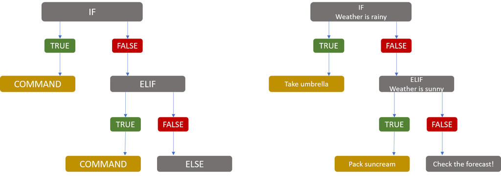

```python
my_height = 6

if my_height == 5:
    print("We're the same height")

else:
    print("Your height is different")
```

```
## Your height is different
```

Remember our `if`, `elif` and `else` statements take a contion so we need a double equals sign (`==`) for checking equivalency.

We can just have an `if`, or we can just have an `if` and an `else`.

If the first criteria isn’t met it will move to an `elif` if one exists and evaluate that statement. If `True` that code will be actioned.

If the `elif` equates to `False` it will skip that code block and move to the next `elif` if one exists. If not it will skip to the `else`.

Note both `if` and `else` are at the same level of indentation with their respective commands indented.

We can add in more choices using an `elif` statement

```python
my_height = 7

if my_height == 5:
    print("We're the same height")

elif my_height > 7:
    print("You're tall!")

else:
    print("Your height is different")
```

```
## Your height is different
```

We can use multiple conditions too - using our logical operators too - & (and) , | (or)

Like our filters each condition gets it’s own set of round brackets.

```python
my_height = 9

if (my_height == 5):
    print("We're the same height")

elif (my_height > 7) & (my_height < 10):
    print("You're tall!")

else:
    print("Your height is different")
```

```
## You're tall!
```

Here we want the action to happen if the value is greater than 7 and less than 10.

The brackets are important as they tell Python to evaluate the elif as a whole.

If we didn’t have the brackets inputing 11 still evaluates as “You’re tall” because it meets the condition `my_height > 7` and performs the action.

```python
my_height = 11

if my_height == 5:
    print("We're the same height")

elif my_height > 7 & my_height < 10:
    print("You're tall!")

elif my_height == 11:
    print("It's 11")
else:
    print("Your height is different")
```

```
## You're tall!
```

It’s important to know how the `if, elif, else` works.

Here we have two option for when the value is 5.

However it will only print out `“We’re the same height!”`

When the condition is met it performs the action associated with it and then stops evaluating the rest of the conditional code.

```python
my_height = 5

if (my_height == 5):
    print("We're the same height")

elif (my_height > 7) & (my_height < 10):
    print("You're tall!")

elif (my_height == 5):
    print("Wow, it's still 5!")

else:
    print("Your height is different")
```

```
## We're the same height
```

Try changing the value stored in `my_height` to see the other results.

If you use other languages you may be used to using switch cases; or `case_when()` in R. Python is starting to introduce switch cases - but from [Python version 3.10](https://towardsdatascience.com/switch-case-statements-are-coming-to-python-d0caf7b2bfd3).

There are ways to implement something similar using either functions or classes. [This tutorial](https://data-flair.training/blogs/python-switch-case/) from Data Flair explains how.

If you’re looking to apply something similar to a DataFrame `np.select()` might be useful and there’s a mini tutorial in the additional materials chapter (8)

## 3.4 Exercise

### **Exercise**

Can you write a loop with an if, elif and else statement, that loops through the numbers from 1 to 30.

- If the number is a multiple of both 3 and 5, print FizzBuzz.
- If the number is a mutiple of 3, print the word Fizz.
- If the number is a mutiple of 5, print the word Buzz.
- For all other values print the number.

You can use the modulus operator for this - this is the % in python, and shows us our remainder.

For example checking if something is completely divisible by 7 we could do

`item % 7 == 0`

If this returns `True` we know it’s divisible by 7, if it returns `False` then it’s not!

```python
# Example of Modulo

10 % 3 == 0

# Returns False (10 / 3 has a remainder of 1 - so does not have a remainder of 0)
```

```
## False
```

```python
# Second example of Modulo

9 % 3 == 0

# Returns True (9 / 3 has a remainder of 0  ))
```

```
## True
```

### **Show Expected Output**

If divisible by 3 and 5 - Fizzbuzz If divisible by 3 - Fizz If divisible by 5 - Buzz

1 2 Fizz 4 Buzz Fizz 7 8 Fizz Buzz 11 Fizz 13 14 FizzBuzz 16 17 Fizz 19 Buzz Fizz 22 23 Fizz Buzz 26 Fizz 28 29 FizzBuzz

### **Pseudocode**

This is pseudo code! Code written in english to help you stucture your code. It will not work if you run it

my_iterable = create a range or a list

for each_thing in my_iterable:

```
if my first conditon(s) :
    action for first conditon

elif my second conditon:
    action for second conditon

elif my third conditon:
    action for third conditon

else:
    action for everything else
```

### **Answer**

```python
# %load ../solutions/chapter_7/control_flow_exercise.py
# Create my list of numbers - here using the list function
# and the range function - remember range is exclusive!

numbers_1_to_30 = range(1, 31)

# Create the control flow

for each_number in numbers_1_to_30:
    if (each_number % 3 == 0) & (each_number % 5 == 0) :
        print("FizzBuzz")
    elif (each_number % 3 == 0) :
         print("Fizz")
    elif (each_number % 5 == 0) :
         print("Buzz")
    else:
        print(each_number)


# Or you could use a while loop

#number = 1

#while number < 31:
#    if (number % 3 == 0) & (number % 5 == 0):
#        print("FizzBuzz")
#    elif (number % 3 == 0):
#        print("Fizz")
#    elif (number % 5 == 0):
#        print("Buzz")
#    else:
#        print(number)
#    number += 1
```

```
## 1
## 2
## Fizz
## 4
## Buzz
## Fizz
## 7
## 8
## Fizz
## Buzz
## 11
## Fizz
## 13
## 14
## FizzBuzz
## 16
## 17
## Fizz
## 19
## Buzz
## Fizz
## 22
## 23
## Fizz
## Buzz
## 26
## Fizz
## 28
## 29
## FizzBuzz
```

## 3.5 List Comprehension

A useful tool within Python is list comprehensions.

I have a list of numbers, and I want to double them.

I can create a new list and use a for loop to append the new list with the numbers doubled – like so:

This method is very robust.

It allows us to store the data in the same order as our original list, and it’s perfect for intermediate to complex cases.

This is especially true if we’re using complex logic, multiple commands and conditional statements.

```python
numbers = [1, 2, 3, 4, 5, 6, 7, 8, 9, 10]

double_list = [] # We can create a blank list to store our doubled numbers

for each_number in numbers:
    double_list.append(each_number * 2)

print(double_list)
```

```
## [2, 4, 6, 8, 10, 12, 14, 16, 18, 20]
```

You may see something called list comprehension here instead. List comprehension condenses down the code into one line.

We put our actions within square brackets `[]` to create our list.

We then write our action. This looks quite similar to how we could write in plain English.

Here – take each_number and multiply it by 2 for each_number in the numbers list.

```python
# take each number in the numbers list and double it

numbers = [1, 2, 3, 4, 5, 6, 7, 8, 9, 10]

double_list_comprehension = [(each_number * 2) for each_number in numbers]

double_list_comprehension
```

```
## [2, 4, 6, 8, 10, 12, 14, 16, 18, 20]
```

Comprehensions can be a really useful tool; here we’re just using a `for` loop - but they can also be used for control flow.

[Geeks for Geeks tutorial on comprehensions](https://www.geeksforgeeks.org/comprehensions-in-python/) is useful for understanding more about this concept and more advanced things you can do with list comprehensions and dictionary comprehensions.

[Corey Schafer’s Youtube Video](https://www.youtube.com/watch?v=3dt4OGnU5sM) on comprehensions and when you should use them is also a great introduction.

Remember though that comprehensions can be harder for humans to read, and require a bit more understanding about how they work. As mentioned above if you have complicated logic or multiple commands using a for loop may be better, and more readable.

return to menu

# 4 Functions

Functions within Python generally fall into three categories:

| Type | Description |
| --- | --- |
| [Built in Functions](https://docs.python.org/3.6/library/functions.html) | These are built into Python and always available for use Examples – `pow()`, `print()`, `help()` |
| User Defined Functions | Created by users to carry out specific tasks. Declared using the `def` keyword. |
| Anonymous Functions – “lambda functions” | User defined - generally one line functions used within a larger piece of code. |

The code inside of user created functions is not run (executed) until we call or run the function. If your code has correct syntax but produces errors this will not be clear until the code is called and executed.

In this section we’re going to focus on User Defined functions.

These functions allow us to organise chunks of reusable code. This can help optimise our code and create blocks of code dedicated to performing a specific procedure or task. Functions can help us to write code that is consistent, readable and reproducible.

## 4.1 Basic Structure of a Function

```python
def my_function_name(parameter_1, parameter_2):
    function_actions
    ...
    return function_output
```

Our functions start with the keyword `def` (define), which is followed by our function name. This: * Must start with a letter or an underscore, * Should be lowercase (by python convention), * Should be short and descriptive, * Can’t have the same name as a python keyword, * Shouldn’t have the name of an existing function (it will overwrite it locally).

Following the function name is brackets. These can contain any necessary parameters that the function will take.

It is finished with a colon, the same as our loops and control flow.

The code below is indented (by 4 spaces, 1 tab or automatically) and is what is executed when the function is called.

The keyword `return` will return whatever value is after it. When the return statement is executed the function will stop at that line and return the given value. No code after the return statement will be executed.

Note that the keyword return is not necessary; but any function without a return statement will return a value of None - it will produce no output for future code to work with.

```python
# Here is a simple function to add together two values and return the sum.
# I need to run this cell to declare my function

def add_two_values(value_1, value_2):
    total = value_1 + value_2
    return total
```

```python
# I can now run my function

add_two_values(1, 2)
```

```
## 3
```

## 4.2 Exercise

### **Exercise**

Write a function that converts from Fahrenheit to degrees Celsius using the equation below.

$C= \frac{5}{9}(F - 32)$

Expected outputs (these are rounded, you don’t need to worry about that for now):

fahrenheit_to_degrees_celsius(32) returns: 0

fahrenheit_to_degrees_celsius(11) returns: -11.7

fahrenheit_to_degrees_celsius(81.3) returns: 27.4

### **Show Answer**

```python
# %load ../solutions/chapter_7/f_to_c.py
#Write a function that converts from Fahrenheit to degrees Celsius using the equation below.

def fahrenheit_to_degrees_celsius(degrees_f):
    degrees_c = (5 / 9) * (degrees_f - 32)
    return degrees_c

fahrenheit_to_degrees_celsius(degrees_f=81.3)
```

```
## 27.38888888888889
```

## 4.3 Extension Exercise

### **Extension Exercise**

Update your function so it rounds to 1 decimal place.

### **Show Answer**

```python
def rnd_fahrenheit_to_degrees_celsius(degrees_f):
    degrees_c = (5 / 9) * (degrees_f - 32)
    return round(degrees_c, 1)

rnd_fahrenheit_to_degrees_celsius(81.3)

# Note the round() function has to be in the return statement.
# I can also save the output of round() to a variable like so:



# def rnd1_fahrenheit_to_degrees_celsius(degrees_f):
#    degrees_c = (5/9) * (degrees_f- 32)
#    rounded_c = round(degrees_c, 1 )
#    return rounded_c

# Note the round() function has to be in the return statement.

#rnd1_fahrenheit_to_degrees_celsius(81.3)
```

```
## 27.4
```

## 4.4 Named parameters

We called the parameters `value_1` and `value_2` - this is a simple function, where we could expect to pass two values to be added together – as the function states. You may see similar functions written like this

```python
def add_two_values(x, y) :
    total = x + y
    return total
```

However `x` and `y` as argument names are not very descriptive, especially if we were writing a more complicated function.

As we have seen through the course we can also use the parameter names here and pass the arguments using an = sign.

```python
add_two_values(value_1=3, value_2=10)
```

```
## 13
```

As we’ve talked about previously using named parameters means we can pass them in any order.

```python
add_two_values(value_2=10, value_1=3)
```

```
## 13
```

## 4.5 Default Values

We can also set default values when we declare a function.

I’ve set `value_1=10` and `value_2=5`

Note now when I run the function without any parameters it uses 10 and 5 as the default values.

```python
def add_two_values(value_1=10 , value_2=5):
    total = value_1 + value_2
    return total

add_two_values()
```

```
## 15
```

Now if I just pass `value_2` it will use the default for `value_1` and add it to my specified `value_2`

```python
add_two_values(value_2=15)
```

```
## 25
```

## 4.6 Scope

It’s important to notice here that the variables I create within my functions – like `total` are not available outside of my function.

This has to do with scope; there are two types: global and local. Variables with global scope are visible and can be accessed anywhere, however ones with local scope are only visible and can only be used within the local area.

When we create a new function we effectively create a new local scope – so the variables we declare within our functions are only available within that local scope.

Trying to return the value stored under `total` will return a `NameError`. Effectively `total` is created when the function is run, and then cleaned up and removed by Python after completion. This makes `return`ing variables very important.

```python
total
```

### 4.6.1 Docstrings

We’ve had a look at several docstrings throughout this course. They’re very useful for finding out what a function or method does, what our parameters are called, and what we should expect to be passed as arguments.

Including our own docstrings in a function is as simple as using three sets of speech marks to surround the information we want to include.

For this function - this is overkill really, but good practice!

```python
def add_two_values(value_1, value_2) :
    """
    This function will add together two values

    value_1 : The first value to add
    value_2 : The second value to add

    Returns: The sum / concatenation of the two values specificed.

    Examples:

    add_two_values(1, 2)
    returns 3

    add_two_values(4.7,  3.2)
    returns 7.9

    add_two_values("Hello", "World")
    returns "HelloWorld" (The + symbol concatenates strings)

    Errors will occur if adding together strings and numerics, unless you use str() around the numeric.

    """
    total = value_1 + value_2
    return total
```

We can now access our docstring in the same ways we do for inbuilt functions:

```python
help(add_two_values)
```

```
## Help on function add_two_values in module __main__:
##
## add_two_values(value_1, value_2)
##     This function will add together two values
##
##     value_1 : The first value to add
##     value_2 : The second value to add
##
##     Returns: The sum / concatenation of the two values specificed.
##
##     Examples:
##
##     add_two_values(1, 2)
##     returns 3
##
##     add_two_values(4.7,  3.2)
##     returns 7.9
##
##     add_two_values("Hello", "World")
##     returns "HelloWorld" (The + symbol concatenates strings)
##
##     Errors will occur if adding together strings and numerics, unless you use str() around the numeric.
```

## 4.7 Helpful Indentation hint!

The indentation of code in functions and loops is incredibly important!

If we’re copying code from other places it can often be not indented correctly to run in our new function.

If you highlight the code you wish to “move” and press * tab - to increase the indent one “level” * shift + tab will decrease the indent one level.

```python
# This cell will give an error - our indentation is off!

def whos_the_best(print_x_times):

for each_num in range(print_x_times):
    print("Hannah is the best!")

# Use the function

whos_the_best(10)
```

This will give us an error!

If we highlight everything from the `for` line down and hit tab we get

```python
def whos_the_best(print_x_times):

    for each_num in range(print_x_times):
        print("Hannah is the best!")


# Use the function

whos_the_best(10)
```

```
## Hannah is the best!
## Hannah is the best!
## Hannah is the best!
## Hannah is the best!
## Hannah is the best!
## Hannah is the best!
## Hannah is the best!
## Hannah is the best!
## Hannah is the best!
## Hannah is the best!
```

much better!

## 4.8 Exercise

### **Exercise**

Returning to the FizzBuzz exercise:

This previously worked over a hard-coded number of values.

**Create a function so the user can find fizzbuzz values for any range of numbers**

If you’ve used a for loop an example could be 1 to 100,

If you’ve used a while loop your top number could be 100.

Make sure you include a docstring.

A reminder for Fizz Buzz:

Can you write a loop with an `if`, `elif` and `else` statement, that loops through the numbers from 1 to 30.

- If the number is a mutiple of 3, print the word Fizz.
- For multiples of 5 print the word Buzz.
- If the number is a multiple of both 3 and 5, print FizzBuzz.
- For all other values print the number.

You can use the modulus operator for this - this is the % in python, and shows us our remainder.

For example checking if something is divisible by 7 we could do

`item % 7 == 0`

If this divided completely it would return `True`, if there was a remainder it would return `False`

### **Pseudo Code**

This is pseudo code! Code written in english to help you stucture your code. It will not work if you run it

def my_function(my_iterable):

```
"""
information about my function in this docstring

"""


for each_thing in my_iterable:

    if my first conditon(s) :
        action for first conditon

    elif my second conditon:
        action for second conditon

    elif my third conditon:
        action for third conditon

    else:
        action for everything else
```

my_function(an_iterable)

### **Show Answer**

```python
def fizz_buzz(my_iterable):

    """
    fizz_buzz takes an iterable and:

    if numbers are divisible by 3 and 5 and returns the value of "FizzBuzz"

    if numbers are divisible by 3 return "Fizz"

    if numbers are divisible by 5 return "Fizz"

    else print out the number


    """
    for each_number in my_iterable:
        if (each_number % 3 == 0) & (each_number % 5 == 0) :
            print("FizzBuzz")
        elif (each_number % 3) == 0 :
            print("Fizz")
        elif (each_number % 5) == 0 :
            print("Buzz")
        else:
            print(each_number)



# Run the function - I'm passing a iterable using the range() function
# which remember is exclusive

fizz_buzz(range(1, 31))

##### Or using a while loop ####

#def fizzbuzz_while(max_number):

#    max_number +=1 # As the last number is exclusive, we can add 1 here
#    number = 1

#    while number < max_number:
#        if (number % 3 == 0) & (number % 5 == 0):
#            print("FizzBuzz")
#        elif (number % 3 == 0):
#            print("Fizz")
#        elif (number % 5 == 0):
#            print("Buzz")
#        else:
#            print(number)
#        number += 1
```

```
## 1
## 2
## Fizz
## 4
## Buzz
## Fizz
## 7
## 8
## Fizz
## Buzz
## 11
## Fizz
## 13
## 14
## FizzBuzz
## 16
## 17
## Fizz
## 19
## Buzz
## Fizz
## 22
## 23
## Fizz
## Buzz
## 26
## Fizz
## 28
## 29
## FizzBuzz
```

This part of the course is a quick overview of functions and how they work.

There’s a whole lot more to be explored; including returning multiple values from a function and lambda functions.

Some additional information about functions can be found:

[Datacamp Python Functions Tutorial](https://www.datacamp.com/community/tutorials/functions-python-tutorial)

[Geeks for Geeks Python Functions Tutorial](https://www.geeksforgeeks.org/functions-in-python/)

[Python Lambda – Anonymous Functions](https://www.geeksforgeeks.org/python-lambda-anonymous-functions-filter-map-reduce/)

return to menu

# 5 Functions for DataFrames

So far we’ve seen how functions work, but how can we apply them to our DataFrames?

I want to: * Remove spaces from my column names and change to underscores * Change column names to lower case * Select just the columns of the “object” data Type.

If I have a few DataFrames to run this for the process can mean a lot of lines of code used for basic cleaning.

Let’s make a copy of our animals data frame.

```python
# Make a copy

animals_new = animals.copy()
```

Now let’s do some basic cleaning.

```python
# replace column spaces with "_"
animals_new.columns = animals_new.columns.str.replace(" ", "_")

# lower case the columns names
animals_new.columns = animals_new.columns.str.lower()

animals_new_objects = animals_new.select_dtypes(["O"])

animals_new_objects
```

| incidentnumber | datetimeofcall | finyear | typeofincident | finaldescription | animalgroupparent | propertytype | specialservicetypecategory | specialservicetype | borough | stngroundname | animalclass | code | london |
| --- | --- | --- | --- | --- | --- | --- | --- | --- | --- | --- | --- | --- | --- |
| 139091 | 01/01/2009 03:01 | 2008/09 | Special Service | DOG WITH JAW TRAPPED IN MAGAZINE RACK,B15 | Dog | House - single occupancy | Other animal assistance | Animal assistance involving livestock - Other action | Croydon | Norbury | Mammal | 00AH | Outer London |
| 275091 | 01/01/2009 08:51 | 2008/09 | Special Service | ASSIST RSPCA WITH FOX TRAPPED,B15 | Fox | Railings | Other animal assistance | Animal assistance involving livestock - Other action | Croydon | Woodside | Mammal | 00AH | Outer London |
| 2075091 | 04/01/2009 10:07 | 2008/09 | Special Service | DOG CAUGHT IN DRAIN,B15 | Dog | Pipe or drain | Animal rescue from below ground | Animal rescue from below ground - Domestic pet | Sutton | Wallington | Mammal | 00BF | Outer London |
| 2872091 | 05/01/2009 12:27 | 2008/09 | Special Service | HORSE TRAPPED IN LAKE,J17 | Horse | Intensive Farming Sheds (chickens, pigs etc) | Animal rescue from water | Animal rescue from water - Farm animal | Hillingdon | Ruislip | Mammal | 00AS | Outer London |
| 3553091 | 06/01/2009 15:23 | 2008/09 | Special Service | RABBIT TRAPPED UNDER SOFA,B15 | Rabbit | House - single occupancy | Other animal assistance | Animal assistance involving livestock - Other action | Havering | Harold Hill | Mammal | 00AR | Outer London |

Without a function for each DataFrame I wanted to do this on I’d have to go in and change the object names.

I can make a function to repeat this same action over and over.

```python
def clean_frame_give_objects(dataframe):
    """
    Function that cleans the column names of the input frame
    It also selects the columns with object data

    Arguments:
        dataframe - pandas dataframe

    Returns:
        dataframe_objects - cleaned columns with
                            only objects
    """
    dataframe.columns = dataframe.columns.str.replace(" " , "_")
    dataframe.columns = dataframe.columns.str.lower()
    dataframe_objects = dataframe.select_dtypes(include = ["O"] )
    return dataframe_objects
```

Our function does the same as our script did.

```python
clean_frame_give_objects(animals)
```

| incidentnumber | datetimeofcall | finyear | typeofincident | finaldescription | animalgroupparent | propertytype | specialservicetypecategory | specialservicetype | borough | stngroundname | animalclass | code | london |
| --- | --- | --- | --- | --- | --- | --- | --- | --- | --- | --- | --- | --- | --- |
| 139091 | 01/01/2009 03:01 | 2008/09 | Special Service | DOG WITH JAW TRAPPED IN MAGAZINE RACK,B15 | Dog | House - single occupancy | Other animal assistance | Animal assistance involving livestock - Other action | Croydon | Norbury | Mammal | 00AH | Outer London |
| 275091 | 01/01/2009 08:51 | 2008/09 | Special Service | ASSIST RSPCA WITH FOX TRAPPED,B15 | Fox | Railings | Other animal assistance | Animal assistance involving livestock - Other action | Croydon | Woodside | Mammal | 00AH | Outer London |
| 2075091 | 04/01/2009 10:07 | 2008/09 | Special Service | DOG CAUGHT IN DRAIN,B15 | Dog | Pipe or drain | Animal rescue from below ground | Animal rescue from below ground - Domestic pet | Sutton | Wallington | Mammal | 00BF | Outer London |
| 2872091 | 05/01/2009 12:27 | 2008/09 | Special Service | HORSE TRAPPED IN LAKE,J17 | Horse | Intensive Farming Sheds (chickens, pigs etc) | Animal rescue from water | Animal rescue from water - Farm animal | Hillingdon | Ruislip | Mammal | 00AS | Outer London |
| 3553091 | 06/01/2009 15:23 | 2008/09 | Special Service | RABBIT TRAPPED UNDER SOFA,B15 | Rabbit | House - single occupancy | Other animal assistance | Animal assistance involving livestock - Other action | Havering | Harold Hill | Mammal | 00AR | Outer London |

We could also expand this loop to allow us to perfom the function on multiple DataFrames.

This would allow us to clean multiple DataFrames at once and store them in a `list` object.

```python
# We can then loop through the list of frames and process them one after another

# Collect our list of frames
list_of_frames = [animals, titanic]

# Create a new blank list to store our frames in

new_frames = []


for each_frame in list_of_frames:
    clean_frame = clean_frame_give_objects(each_frame)
    new_frames.append(clean_frame)
```

We can then sub select each DataFrame from our list like so:

```python
# selects the datafame at position 0 in our list

new_frames[0].head()
```

| incidentnumber | datetimeofcall | finyear | typeofincident | finaldescription | animalgroupparent | propertytype | specialservicetypecategory | specialservicetype | borough | stngroundname | animalclass | code | london |
| --- | --- | --- | --- | --- | --- | --- | --- | --- | --- | --- | --- | --- | --- |
| 139091 | 01/01/2009 03:01 | 2008/09 | Special Service | DOG WITH JAW TRAPPED IN MAGAZINE RACK,B15 | Dog | House - single occupancy | Other animal assistance | Animal assistance involving livestock - Other action | Croydon | Norbury | Mammal | 00AH | Outer London |
| 275091 | 01/01/2009 08:51 | 2008/09 | Special Service | ASSIST RSPCA WITH FOX TRAPPED,B15 | Fox | Railings | Other animal assistance | Animal assistance involving livestock - Other action | Croydon | Woodside | Mammal | 00AH | Outer London |
| 2075091 | 04/01/2009 10:07 | 2008/09 | Special Service | DOG CAUGHT IN DRAIN,B15 | Dog | Pipe or drain | Animal rescue from below ground | Animal rescue from below ground - Domestic pet | Sutton | Wallington | Mammal | 00BF | Outer London |
| 2872091 | 05/01/2009 12:27 | 2008/09 | Special Service | HORSE TRAPPED IN LAKE,J17 | Horse | Intensive Farming Sheds (chickens, pigs etc) | Animal rescue from water | Animal rescue from water - Farm animal | Hillingdon | Ruislip | Mammal | 00AS | Outer London |
| 3553091 | 06/01/2009 15:23 | 2008/09 | Special Service | RABBIT TRAPPED UNDER SOFA,B15 | Rabbit | House - single occupancy | Other animal assistance | Animal assistance involving livestock - Other action | Havering | Harold Hill | Mammal | 00AR | Outer London |

```python
# selects the datafame at position 1 in our list

new_frames[1].head()
```

| name | sex | ticket | cabin | embarked | home.dest | boat |
| --- | --- | --- | --- | --- | --- | --- |
| Allen, Miss. Elisabeth Walton | female | 24160 | B5 | S | St Louis, MO | 2 |
| Allison, Master. Hudson Trevor | male | 113781 | C22 C26 | S | Montreal, PQ / Chesterville, ON | 11 |
| Allison, Miss. Helen Loraine | female | 113781 | C22 C26 | S | Montreal, PQ / Chesterville, ON | NaN |
| Allison, Mr. Hudson Joshua Creighton | male | 113781 | C22 C26 | S | Montreal, PQ / Chesterville, ON | NaN |
| Allison, Mrs. Hudson J C (Bessie Waldo Daniels) | female | 113781 | C22 C26 | S | Montreal, PQ / Chesterville, ON | NaN |

return to menu

# 6 Chapter Summary

In this chapter we’ve explored:

- Comparison and Logical Operators
- For Loops
- While Loops
- Control flow (If, Elif and Else conditions)
- List comprehension
- Basic Functions
- Exploring parameters, default values and scope
- Application of functions to DataFrames.

You have completed chapter 7 of the Introduction to Python course.

Please ensure you complete the post course survey on the Learning Hub to complete your learning.